# 4550 Final Project

1. Variable Selection

```r
dat <- xts::cbind.xts(LFPR,
                      UNRATE,
                      1/log(INFLATION),
                      1/POPLEVEL)
names(dat) <- c('LFPR', 'UNRATE', 'INFLATION', 'POPLEVEL')
```

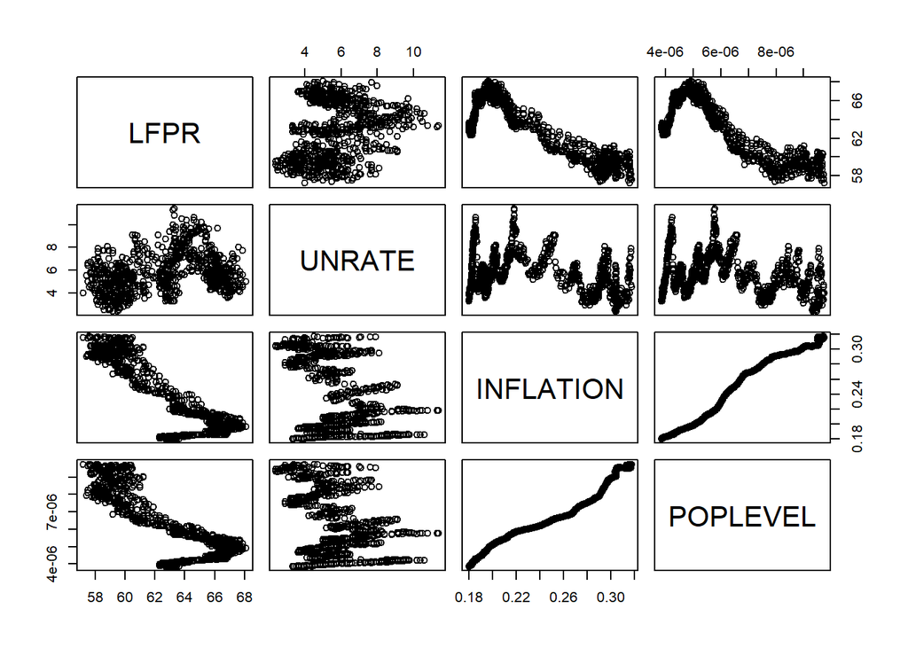

```r
pairs(data.frame(dat))
```

```r
cor(dat)
```

```
##                 LFPR     UNRATE  INFLATION   POPLEVEL
## LFPR       1.0000000  0.2547739 -0.8712033 -0.8247537
## UNRATE     0.2547739  1.0000000 -0.3161169 -0.3087008
## INFLATION -0.8712033 -0.3161169  1.0000000  0.9893472
## POPLEVEL  -0.8247537 -0.3087008  0.9893472  1.0000000
```

```r
summary(lm(LFPR~UNRATE, data=dat)) # very poor R^2
```

```
##
## Call:
## lm(formula = LFPR ~ UNRATE, data = dat)
##
## Residuals:
##     Min      1Q  Median      3Q     Max
## -5.7823 -2.4758 -0.1224  2.8652  5.5837
##
## Coefficients:
##             Estimate Std. Error t value Pr(>|t|)
## (Intercept) 60.24621    0.35552 169.459  < 2e-16 ***
## UNRATE       0.46002    0.05947   7.735 2.88e-14 ***
## ---
## Signif. codes:  0 '***' 0.001 '**' 0.01 '*' 0.05 '.' 0.1 ' ' 1
##
## Residual standard error: 2.957 on 862 degrees of freedom
## Multiple R-squared:  0.06491,    Adjusted R-squared:  0.06382
## F-statistic: 59.84 on 1 and 862 DF,  p-value: 2.876e-14
```

```r
summary(lm(LFPR~INFLATION, data=dat))
```

```
##
## Call:
## lm(formula = LFPR ~ INFLATION, data = dat)
##
## Residuals:
##     Min      1Q  Median      3Q     Max
## -3.6694 -0.9499  0.2099  1.1661  3.1992
##
## Coefficients:
##             Estimate Std. Error t value Pr(>|t|)
## (Intercept)  76.2446     0.2615   291.6   <2e-16 ***
## INFLATION   -56.6464     1.0872   -52.1   <2e-16 ***
## ---
## Signif. codes:  0 '***' 0.001 '**' 0.01 '*' 0.05 '.' 0.1 ' ' 1
##
## Residual standard error: 1.501 on 862 degrees of freedom
## Multiple R-squared:  0.759,  Adjusted R-squared:  0.7587
## F-statistic:  2715 on 1 and 862 DF,  p-value: < 2.2e-16
```

```r
summary(lm(LFPR~POPLEVEL, data=dat))
```

```
##
## Call:
## lm(formula = LFPR ~ POPLEVEL, data = dat)
##
## Residuals:
##     Min      1Q  Median      3Q     Max
## -3.7838 -1.4120  0.1888  1.4355  3.6229
##
## Coefficients:
##               Estimate Std. Error t value Pr(>|t|)
## (Intercept)  7.141e+01  2.076e-01  344.03   <2e-16 ***
## POPLEVEL    -1.367e+06  3.192e+04  -42.82   <2e-16 ***
## ---
## Signif. codes:  0 '***' 0.001 '**' 0.01 '*' 0.05 '.' 0.1 ' ' 1
##
## Residual standard error: 1.729 on 862 degrees of freedom
## Multiple R-squared:  0.6802, Adjusted R-squared:  0.6798
## F-statistic:  1834 on 1 and 862 DF,  p-value: < 2.2e-16
```

Based on this, we drop UNRATE from our dataframe, and only keep LFPR with 1/log(INFLATION) and 1/POPLEVEL.

```r
dat <- dat[ , !names(dat)=='UNRATE']
```

2. Construct VAR Model

```r
freq = 1/12
df = data.frame(trend = 1:nrow(dat),
                cos1 = cos(2*pi*freq*1:nrow(dat)),
                sin1 = sin(2*pi*freq*1:nrow(dat)))
VARselect(dat, type = "const", exogen = df, lag.max=30)$selection
```

```
## AIC(n)  HQ(n)  SC(n) FPE(n)
##     25     14     14     25
```

```r
                                                   # AIC: -58.919
var.model <- VAR(dat, p = 25, type = "const", exogen = df)
```

```r
freq = 1/12
df = data.frame(cos1 = cos(2*pi*freq*1:nrow(dat)),
                sin1 = sin(2*pi*freq*1:nrow(dat)))
VARselect(dat, type = "const", exogen = df, lag.max=30)$selection
```

```
## AIC(n)  HQ(n)  SC(n) FPE(n)
##     25     14     14     25
```

```r
                                                   # AIC: -58.900
var.model <- VAR(dat, p = 25, type = "const", exogen = df)
```

```r
df = data.frame(trend = 1:nrow(dat))
VARselect(dat, type = "const", exogen = df, lag.max=30)$selection
```

```
## AIC(n)  HQ(n)  SC(n) FPE(n)
##     25     14     14     25
```

```r
                                                   # AIC: -58.901
var.model <- VAR(dat, p = 25, type = "const", exogen = df)
```

```r
VARselect(dat, type = "const", lag.max=30)$selection
```

```
## AIC(n)  HQ(n)  SC(n) FPE(n)
##     25     14     14     25
```

```r
                                      # AIC: -58.881
var.model <- VAR(dat, p = 25, type = "const")
```

```r
freq = 1/12
freq1 = 1/6

df = data.frame(cos1 = cos(2*pi*freq*1:nrow(dat)),
                sin1 = sin(2*pi*freq*1:nrow(dat)),
                cos2 = cos(2*pi*freq1*1:nrow(dat)),
                sin2 = sin(2*pi*freq1*1:nrow(dat)))
VARselect(dat, type = "const", exogen = df, lag.max=30)$selection
```

```
## AIC(n)  HQ(n)  SC(n) FPE(n)
##     25     14     14     25
```

```r
                                                   # AIC: -58.914
var.model <- VAR(dat, p = 25, type = "const", exogen = df)
```

```r
freq = 1/12
freq1 = 1/6

df = data.frame(trend = 1:nrow(dat),
                cos1 = cos(2*pi*freq*1:nrow(dat)),
                sin1 = sin(2*pi*freq*1:nrow(dat)),
                cos2 = cos(2*pi*freq1*1:nrow(dat)),
                sin2 = sin(2*pi*freq1*1:nrow(dat)))
VARselect(dat, type = "const", exogen = df, lag.max=30)$selection
```

```
## AIC(n)  HQ(n)  SC(n) FPE(n)
##     25     14     14     25
```

```r
                                                   # AIC: -58.933
var.model <- VAR(dat, p = 25, type = "const", exogen = df)
```

```r
freq = 1/12
freq1 = 1/6
freq2 = 1/4

df = data.frame(cos1 = cos(2*pi*freq*1:nrow(dat)),
                sin1 = sin(2*pi*freq*1:nrow(dat)),
                cos2 = cos(2*pi*freq1*1:nrow(dat)),
                sin2 = sin(2*pi*freq1*1:nrow(dat)),
                cos3 = cos(2*pi*freq2*1:nrow(dat)),
                sin3 = sin(2*pi*freq2*1:nrow(dat)))
VARselect(dat, type = "const", exogen = df, lag.max=30)$selection
```

```
## AIC(n)  HQ(n)  SC(n) FPE(n)
##     25     15     14     25
```

```r
                                                   # AIC: -58.928
var.model <- VAR(dat, p = 25, type = "const", exogen = df)
```

```r
freq = 1/12
freq1 = 1/6
freq2 = 1/4

df = data.frame(trend = 1:nrow(dat),
                cos1 = cos(2*pi*freq*1:nrow(dat)),
                sin1 = sin(2*pi*freq*1:nrow(dat)),
                cos2 = cos(2*pi*freq1*1:nrow(dat)),
                sin2 = sin(2*pi*freq1*1:nrow(dat)),
                cos3 = cos(2*pi*freq2*1:nrow(dat)),
                sin3 = sin(2*pi*freq2*1:nrow(dat)))
VARselect(dat, type = "const", exogen = df, lag.max=30)$selection
```

```
## AIC(n)  HQ(n)  SC(n) FPE(n)
##     25     15     14     25
```

```r
                                                   # BEST MODEL!
                                                   # AIC: -58.947
best.var.model <- VAR(dat, p = 25, type = "const", exogen = df)
```

```r
summary(best.var.model)$varresult$LFPR
```

```
##
## Call:
## lm(formula = y ~ -1 + ., data = datamat)
##
## Residuals:
##      Min       1Q   Median       3Q      Max
## -0.65445 -0.11719  0.00663  0.12516  0.60602
##
## Coefficients:
##                 Estimate Std. Error t value Pr(>|t|)
## LFPR.l1        6.615e-01  3.570e-02  18.529  < 2e-16 ***
## INFLATION.l1  -9.924e+01  4.487e+01  -2.212  0.02728 *
## POPLEVEL.l1   -2.559e+06  1.738e+06  -1.472  0.14146
## LFPR.l2        1.219e-01  4.199e-02   2.903  0.00380 **
## INFLATION.l2   6.054e+01  7.152e+01   0.846  0.39756
## POPLEVEL.l2    4.393e+05  2.566e+06   0.171  0.86411
## LFPR.l3       -3.001e-03  4.177e-02  -0.072  0.94275
## INFLATION.l3   9.534e+01  7.021e+01   1.358  0.17490
## POPLEVEL.l3    8.669e+05  2.560e+06   0.339  0.73499
## LFPR.l4        7.337e-02  4.179e-02   1.756  0.07950 .
## INFLATION.l4  -6.323e+01  6.925e+01  -0.913  0.36154
## POPLEVEL.l4    1.092e+06  2.546e+06   0.429  0.66804
## LFPR.l5       -4.827e-02  4.181e-02  -1.155  0.24862
## INFLATION.l5  -1.788e+01  6.835e+01  -0.262  0.79369
## POPLEVEL.l5   -3.232e+06  2.552e+06  -1.267  0.20571
## LFPR.l6        2.824e-02  4.181e-02   0.675  0.49964
## INFLATION.l6   1.162e+02  6.831e+01   1.701  0.08943 .
## POPLEVEL.l6    7.174e+06  2.555e+06   2.807  0.00513 **
## LFPR.l7        1.176e-01  4.167e-02   2.824  0.00487 **
## INFLATION.l7  -9.588e+01  6.671e+01  -1.437  0.15109
## POPLEVEL.l7   -2.613e+06  2.568e+06  -1.018  0.30909
## LFPR.l8       -8.127e-02  4.208e-02  -1.931  0.05383 .
## INFLATION.l8  -1.040e+02  6.588e+01  -1.579  0.11472
## POPLEVEL.l8   -3.777e+04  2.568e+06  -0.015  0.98827
## LFPR.l9        4.043e-02  4.202e-02   0.962  0.33631
## INFLATION.l9   6.992e+01  6.544e+01   1.068  0.28565
## POPLEVEL.l9   -7.547e+05  2.543e+06  -0.297  0.76671
## LFPR.l10      -8.585e-03  4.174e-02  -0.206  0.83709
## INFLATION.l10  1.500e+02  6.528e+01   2.298  0.02184 *
## POPLEVEL.l10   2.791e+06  2.534e+06   1.101  0.27113
```

[output cut: 44 more lines]

```
## POPLEVEL.l25   8.235e+05  1.698e+06   0.485  0.62781
## const          4.022e+00  1.051e+00   3.828  0.00014 ***
## trend         -1.245e-03  3.088e-04  -4.030 6.14e-05 ***
## cos1          -7.064e-02  2.706e-02  -2.610  0.00923 **
## sin1          -2.038e-02  2.743e-02  -0.743  0.45774
## cos2           5.629e-02  2.113e-02   2.664  0.00788 **
## sin2          -4.581e-02  2.119e-02  -2.162  0.03094 *
## cos3          -4.213e-02  3.022e-02  -1.394  0.16368
## sin3          -9.494e-02  2.990e-02  -3.175  0.00156 **
## ---
## Signif. codes:  0 '***' 0.001 '**' 0.01 '*' 0.05 '.' 0.1 ' ' 1
##
## Residual standard error: 0.2024 on 756 degrees of freedom
## Multiple R-squared:  0.9959, Adjusted R-squared:  0.9955
## F-statistic:  2258 on 82 and 756 DF,  p-value: < 2.2e-16
```

```r
summary(best.var.model)$corres
```

```
##                  LFPR   INFLATION    POPLEVEL
## LFPR       1.00000000  0.05154618 -0.01352365
## INFLATION  0.05154618  1.00000000 -0.08796712
## POPLEVEL  -0.01352365 -0.08796712  1.00000000
```

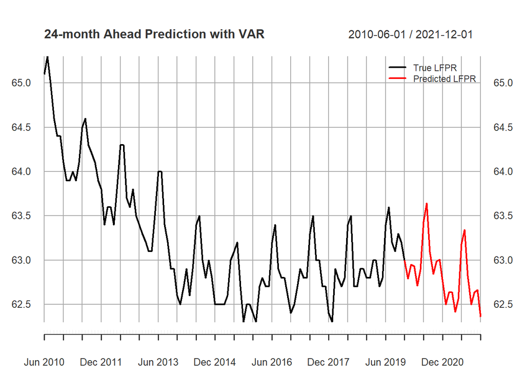

```r
addLegend("topright", legend.names = c('True LFPR', 'Predicted LFPR'),
          col = c('black', 'red'), lty = 1, lwd = 2, cex = 0.8)
```

3. Granger Causality

```r
df_INFLATION = data.frame(trend = 1:nrow(dat),
                          cos1 = cos(2*pi*freq*1:nrow(dat)),
                          sin1 = sin(2*pi*freq*1:nrow(dat)),
                          cos2 = cos(2*pi*freq1*1:nrow(dat)),
                          sin2 = sin(2*pi*freq1*1:nrow(dat)),
                          cos3 = cos(2*pi*freq2*1:nrow(dat)),
                          sin3 = sin(2*pi*freq2*1:nrow(dat)),
                          dat$POPLEVEL)
VARselect(dat[, c('LFPR', 'INFLATION')],
          type = "const",
          exogen = df_INFLATION,
          lag.max = 50)$selection
```

```
## AIC(n)  HQ(n)  SC(n) FPE(n)
##     49     15     14     49
```

```r
var.model <- VAR(dat[, c('LFPR', 'INFLATION')],
                 p=49, type = "const", exogen = df_INFLATION)
causality(var.model, cause = "INFLATION")$Granger
```

```
##
##  Granger causality H0: INFLATION do not Granger-cause LFPR
##
## data:  VAR object var.model
## F-Test = 1.6565, df1 = 49, df2 = 1416, p-value = 0.003235
```

```r
df_POPLEVEL = data.frame(trend = 1:nrow(dat),
                         cos1 = cos(2*pi*freq*1:nrow(dat)),
                         sin1 = sin(2*pi*freq*1:nrow(dat)),
                         cos2 = cos(2*pi*freq1*1:nrow(dat)),
                         sin2 = sin(2*pi*freq1*1:nrow(dat)),
                         cos3 = cos(2*pi*freq2*1:nrow(dat)),
                         sin3 = sin(2*pi*freq2*1:nrow(dat)),
                         dat$INFLATION)
VARselect(dat[, c('LFPR', 'POPLEVEL')],
          type = "const",
          exogen = df_POPLEVEL,
          lag.max = 50)$selection
```

```
## AIC(n)  HQ(n)  SC(n) FPE(n)
##     25     15     14     25
```

```r
var.model <- VAR(dat[, c('LFPR', 'POPLEVEL')],
                 p=49, type = "const", exogen = df_POPLEVEL)
causality(var.model, cause = "POPLEVEL")$Granger
```

```
##
##  Granger causality H0: POPLEVEL do not Granger-cause LFPR
##
## data:  VAR object var.model
## F-Test = 1.3161, df1 = 49, df2 = 1416, p-value = 0.07242
```

Model Comparison

1. Predictions Plots

```r
date_range <- seq(as.Date("1948-01-01"),
                  as.Date("2019-12-01"), by = "1 month")

sarima_fitted <- fitted(best.sarima.model)
sarima_fitted <- xts(sarima_fitted, order.by = date_range)

var_fitted <- c(as.numeric(LFPR[1:best.var.model$p]),
                fitted(best.var.model)[,'LFPR'])
var_fitted <- xts(var_fitted, order.by = date_range)

combined_xts <- merge(LFPR, sarima_fitted, var_fitted)
```

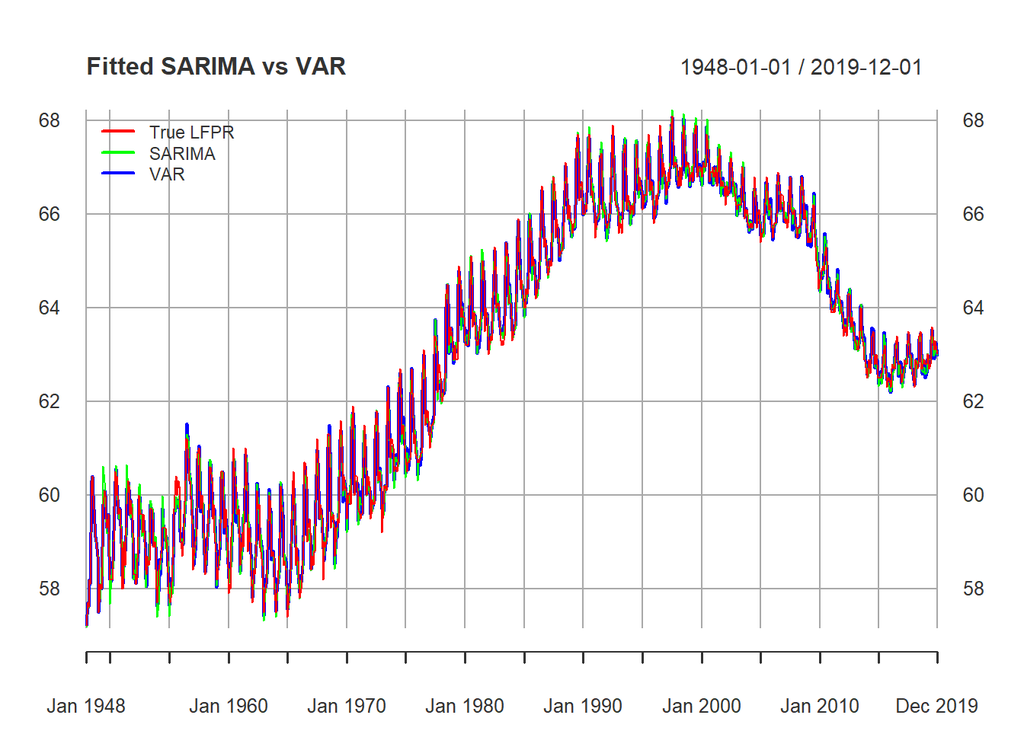

```r
addLegend("topleft", legend.names = c('True LFPR', 'SARIMA', 'VAR'),
          col = colors, lty = 1, lwd = 2, cex = 0.8)
```

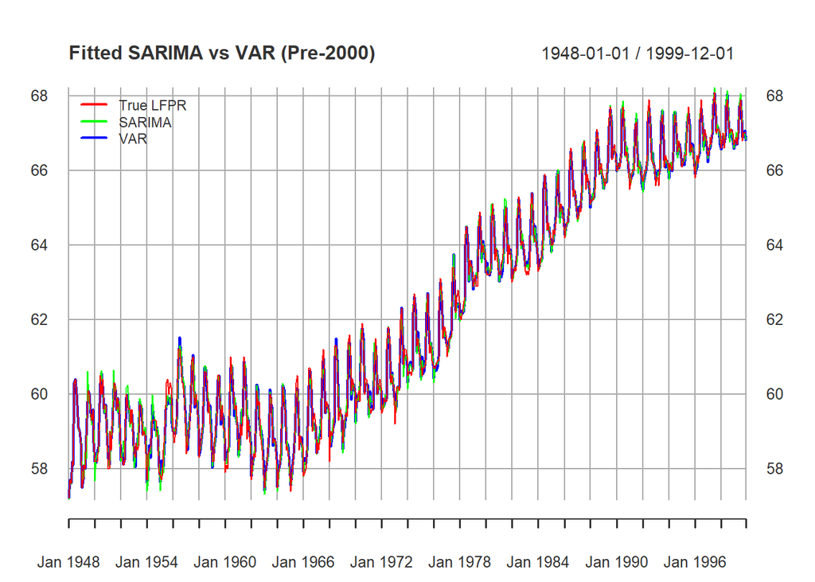

```r
addLegend("topleft", legend.names = c('True LFPR', 'SARIMA', 'VAR'),
          col = colors, lty = 1, lwd = 2, cex = 0.8)
```

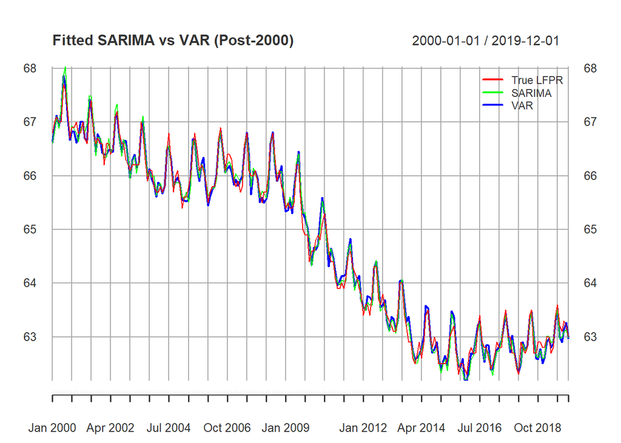

```r
addLegend("topright", legend.names = c('True LFPR', 'SARIMA', 'VAR'),
          col = colors, lty = 1, lwd = 2, cex = 0.8)
```

```r
ahead = 24
dates_ahead <- seq(as.Date("2020-01-01"),
                   as.Date("2020-01-01")+ months(ahead-1),
                   by = "1 month")

# VAR Predictions
df2 = data.frame(trend = 1:ahead+nrow(dat),
                 cos1 = cos(2*pi*freq*(1:ahead+nrow(dat))),
                 sin1 = sin(2*pi*freq*(1:ahead+nrow(dat))),
                 cos2 = cos(2*pi*freq1*(1:ahead+nrow(dat))),
                 sin2 = sin(2*pi*freq1*(1:ahead+nrow(dat))),
                 cos3 = cos(2*pi*freq2*(1:ahead+nrow(dat))),
                 sin3 = sin(2*pi*freq2*(1:ahead+nrow(dat))))
pred.var <- predict(best.var.model, dumvar = df2,
                    n.ahead = ahead)$fcst$LFPR[,1]
pred.var <- rbind(LFPR[864], xts(pred.var, order.by = dates_ahead))

# SARIMA Predictions
pred.sarima <- sarima.for(LFPR, n.ahead = ahead, plot = F,
                          p=2, d=1, q=2, P=1, D=1, Q=2, S=12)$pred
pred.sarima <- rbind(LFPR[864], xts(pred.sarima, order.by = dates_ahead))
```

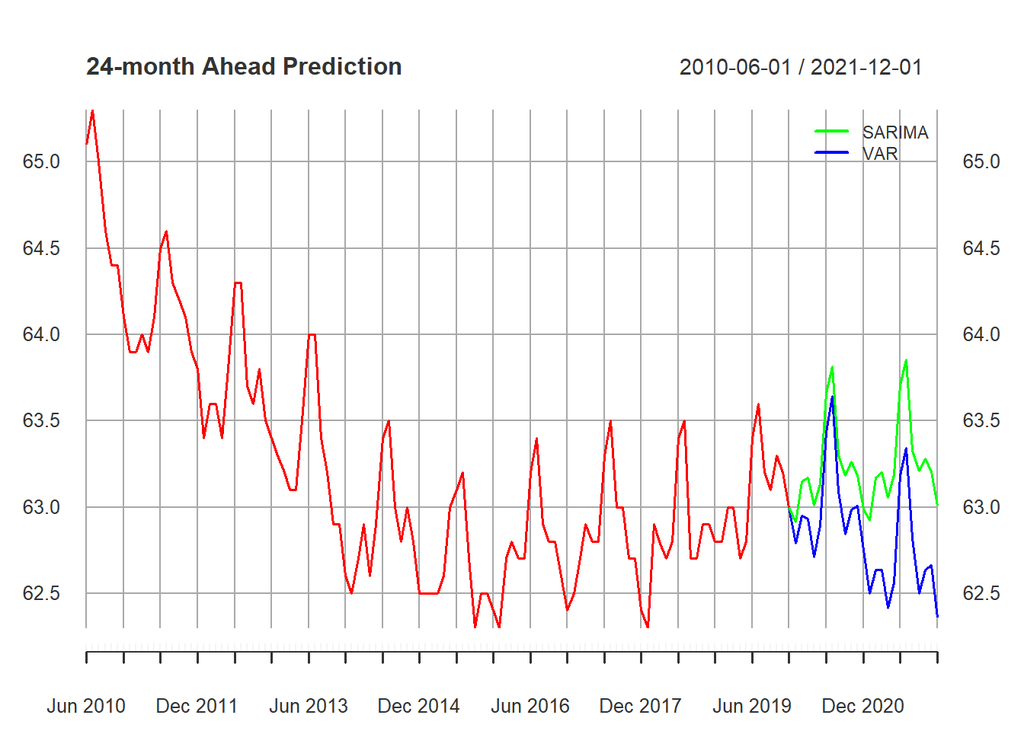

```r
addLegend("topright", col = colors[2:3], lty = 1, lwd = 2, cex = 0.8,
          legend.names = c('SARIMA', 'VAR'))
```

This plot here shows the 24-step ahead prediction using each model.

2. Out-of-sample Error (2010-2019)

```r
ahead = 120
dates_ahead <- seq(as.Date("2020-01-01") - months(ahead),
                   as.Date("2019-12-01"), by = "1 month")
LFPR_train <- LFPR[1:(864-ahead)]
LFPR_test <- LFPR[(864-ahead):864]
```

```r
# SARIMA Model MSE
pred.sarima <- sarima.for(LFPR_train, n.ahead = ahead, plot = F,
                          p=2, d=1, q=2, P=1, D=1, Q=2, S=12)$pred
pred.sarima <- xts(pred.sarima, order.by = dates_ahead)
mse.sarima <- (1/ahead)*sum((LFPR_test - pred.sarima)^2)
print(mse.sarima)
```

```
## [1] 0.5161911
```

```r
# VAR Model MSE
dat_train <- dat[1:(864-ahead),]
df = data.frame(trend = 1:nrow(dat_train),
                cos1 = cos(2*pi*freq*1:nrow(dat_train)),
                sin1 = sin(2*pi*freq*1:nrow(dat_train)),
                cos2 = cos(2*pi*freq1*1:nrow(dat_train)),
                sin2 = sin(2*pi*freq1*1:nrow(dat_train)),
                cos3 = cos(2*pi*freq2*1:nrow(dat_train)),
                sin3 = sin(2*pi*freq2*1:nrow(dat_train)))
test.var.model <- VAR(dat_train, p = 25, type = "const", exogen = df)
df2 = data.frame(trend = 1:ahead+nrow(dat_train),
                 cos1 = cos(2*pi*freq*(1:ahead+nrow(dat_train))),
                 sin1 = sin(2*pi*freq*(1:ahead+nrow(dat_train))),
                 cos2 = cos(2*pi*freq1*(1:ahead+nrow(dat_train))),
                 sin2 = sin(2*pi*freq1*(1:ahead+nrow(dat_train))),
                 cos3 = cos(2*pi*freq2*(1:ahead+nrow(dat_train))),
                 sin3 = sin(2*pi*freq2*(1:ahead+nrow(dat_train))))
pred.var <- predict(test.var.model, dumvar = df2,
                    n.ahead = ahead)$fcst$LFPR[,1]
pred.var <- xts(pred.var, order.by = dates_ahead)
mse.var <- (1/ahead)*sum((LFPR_test - pred.var)^2)
print(mse.var)
```

```
## [1] 1.208616
```

It should be noted that although in this case the SARIMA model has a lower out-of-sample error than the VAR model, in certain cases VAR performs better (i.e. ahead = a different number). The trend is very hard to predict since if the cutoff of a training set is a turning point, the predictions would fail miserably. However, the TBATS model (see the last part) is still able to capture this surprisingly well, although we are not including it into our report, since it is not a model type that can clearly answer our research questions despite a superior fit.

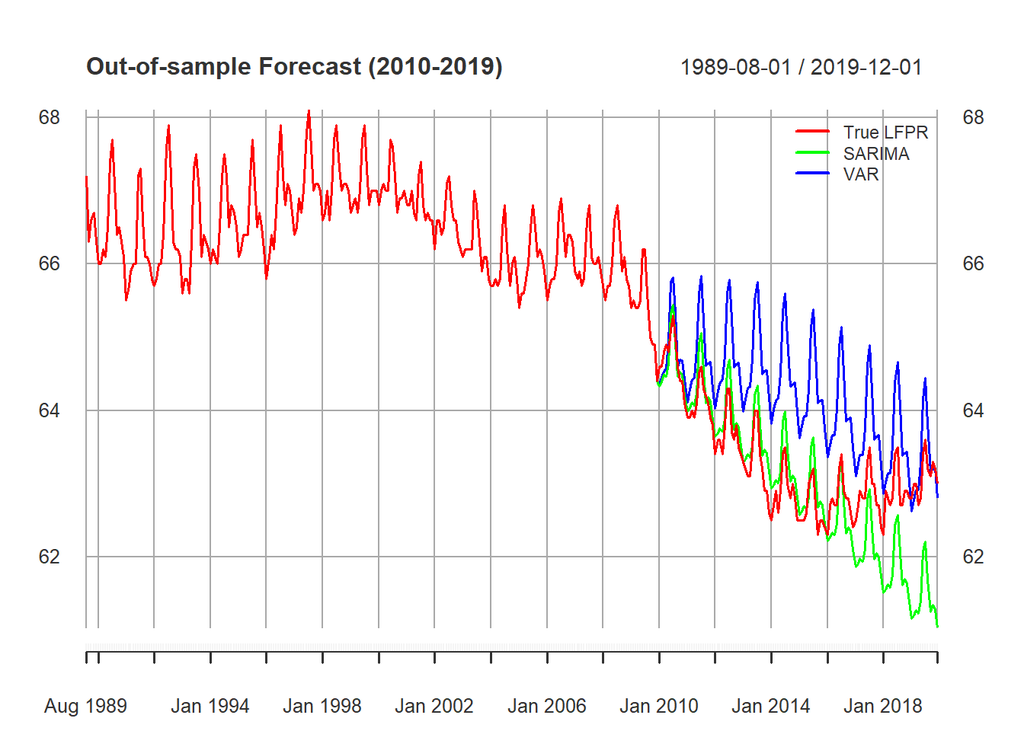

```r
addLegend("topright", col = colors, lty = 1, lwd = 2, cex = 0.8,
          legend.names = c('True LFPR', 'SARIMA', 'VAR'))
```

Additional Ideas (not included in our report)

TBATS State-Space Model (specifically designed to handle multiple seasonal patterns)

```r
tbats.model <- tbats(LFPR2, seasonal.periods = 12)
print(tbats.model) # AIC: 3531.981
```

```
## TBATS(1, {5,0}, 0.803, {<12,5>})
##
## Call: tbats(y = LFPR2, seasonal.periods = 12)
##
## Parameters
##   Alpha: -0.0547951
##   Beta: 0.1215533
##   Damping Parameter: 0.802768
##   Gamma-1 Values: 0.001166057
##   Gamma-2 Values: -0.0002729506
##   AR coefficients: 0.642191 0.07988 -0.275283 0.155326 -0.334712
##
## Seed States:
##                [,1]
##  [1,] 58.6594239490
##  [2,]  0.0844542233
##  [3,] -0.6661912538
##  [4,]  0.2110512057
##  [5,] -0.2543174101
##  [6,]  0.0007449031
##  [7,]  0.0219903493
##  [8,] -0.1735589402
##  [9,] -0.1331289634
## [10,]  0.0810083729
## [11,] -0.0323481556
## [12,] -0.0107419920
## [13,]  0.0000000000
## [14,]  0.0000000000
## [15,]  0.0000000000
## [16,]  0.0000000000
## [17,]  0.0000000000
##
## Sigma: 0.2545989
## AIC: 3531.981
```

```r
tbats.model <- tbats(LFPR2, seasonal.periods = c(12,6))
print(tbats.model) # AIC: 3563.784
```

```
## TBATS(1, {5,2}, -, {<6,3>, <12,1>})
##
## Call: tbats(y = LFPR2, seasonal.periods = c(12, 6))
##
## Parameters
##   Alpha: 0.2437036
##   Gamma-1 Values: 7.911621e-05 0.0002711854
##   Gamma-2 Values: 5.678655e-05 -0.0001815337
##   AR coefficients: 0.656409 -0.880917 0.33581 0.099742 -0.298949
##   MA coefficients: -0.095559 0.890334
##
## Seed States:
##                [,1]
##  [1,]  5.874795e+01
##  [2,]  2.108277e-01
##  [3,]  6.425073e-04
##  [4,] -1.060403e-01
##  [5,] -1.334927e-01
##  [6,] -3.266369e-02
##  [7,] -1.030372e+12
##  [8,] -6.669111e-01
##  [9,] -1.742185e-01
## [10,]  0.000000e+00
## [11,]  0.000000e+00
## [12,]  0.000000e+00
## [13,]  0.000000e+00
## [14,]  0.000000e+00
## [15,]  0.000000e+00
## [16,]  0.000000e+00
##
## Sigma: 0.259028
## AIC: 3563.784
```

```r
best.tbats.model <- tbats(LFPR2, seasonal.periods = c(216,144,72,12))
print(best.tbats.model) # AIC: 3463.498 - BEST MODEL!
```

```
## TBATS(1, {5,4}, -, {<12,6>, <72,1>, <144,1>, <216,1>})
##
## Call: tbats(y = LFPR2, seasonal.periods = c(216, 144, 72, 12))
##
## Parameters
##   Alpha: 0.3068854
##   Gamma-1 Values: 2.463633e-05 1.338189e-05 8.932051e-06 -4.384574e-05
##   Gamma-2 Values: -5.184307e-05 -1.956346e-05 1.414685e-05 -2.559407e-05
##   AR coefficients: 0.71264 0.127657 0.250369 -0.920967 0.185717
##   MA coefficients: -0.342932 -0.272198 -0.405352 0.858937
##
## Seed States:
##                [,1]
##  [1,]  5.872659e+01
##  [2,] -6.667927e-01
##  [3,]  2.109461e-01
##  [4,] -2.543316e-01
##  [5,]  7.609436e-04
##  [6,]  2.201827e-02
##  [7,] -1.050125e-01
##  [8,] -1.737676e-01
##  [9,] -1.332824e-01
## [10,]  8.083714e-02
## [11,] -3.259014e-02
## [12,] -1.121721e-02
## [13,] -1.012062e+12
## [14,] -3.171551e-02
## [15,]  4.385161e-02
## [16,]  8.437852e-02
## [17,] -2.322144e-02
## [18,] -8.728584e-02
## [19,]  1.654087e-01
## [20,]  0.000000e+00
## [21,]  0.000000e+00
## [22,]  0.000000e+00
## [23,]  0.000000e+00
## [24,]  0.000000e+00
## [25,]  0.000000e+00
## [26,]  0.000000e+00
## [27,]  0.000000e+00
## [28,]  0.000000e+00
##
## Sigma: 0.2393836
## AIC: 3463.498
```

```r
tbats.model <- tbats(LFPR2, seasonal.periods = c(216,144,72,12,6))
print(tbats.model) # AIC: 3580.569
```

```
## TBATS(1, {5,2}, 1, {<6,3>, <12,1>, <72,1>, <144,1>, <216,1>})
##
## Call: tbats(y = LFPR2, seasonal.periods = c(216, 144, 72, 12, 6))
##
## Parameters
##   Alpha: 0.1476255
##   Beta: 0.01030555
##   Damping Parameter: 1
##   Gamma-1 Values: 3.249832e-05 -2.255698e-05 6.026648e-05 8.103686e-05 -2.161838e-06
##   Gamma-2 Values: 5.350942e-08 -6.561046e-05 -6.008953e-05 -7.296117e-06 3.599386e-05
##   AR coefficients: 0.722855 -0.896288 0.416529 0.084244 -0.28431
##   MA coefficients: -0.096109 0.894072
##
## Seed States:
##                [,1]
##  [1,]  5.836782e+01
##  [2,]  7.778865e-02
##  [3,]  2.111885e-01
##  [4,]  8.837070e-04
##  [5,] -1.060968e-01
##  [6,] -1.331794e-01
##  [7,] -3.255988e-02
##  [8,] -1.033577e+12
##  [9,] -6.660599e-01
## [10,] -1.735432e-01
## [11,] -8.069036e-03
## [12,]  4.523260e-02
## [13,]  1.787307e-01
## [14,] -2.045797e-02
## [15,]  1.249093e-01
## [16,]  1.695543e-01
## [17,]  0.000000e+00
## [18,]  0.000000e+00
## [19,]  0.000000e+00
## [20,]  0.000000e+00
## [21,]  0.000000e+00
## [22,]  0.000000e+00
## [23,]  0.000000e+00
##
## Sigma: 0.2573525
## AIC: 3580.569
```

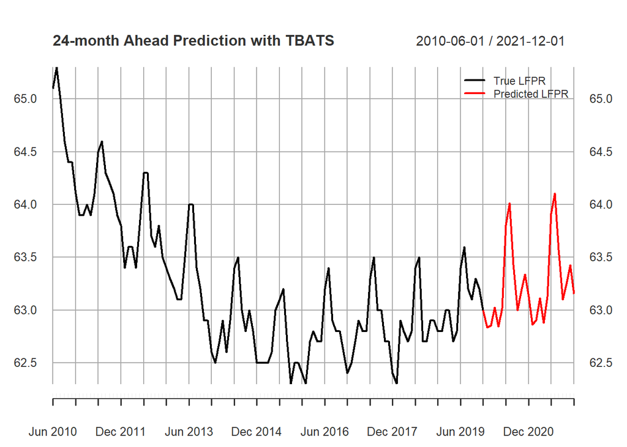

```r
addLegend("topright", legend.names = c('True LFPR', 'Predicted LFPR'),
          col = c('black', 'red'), lty = 1, lwd = 2, cex = 0.8)
```

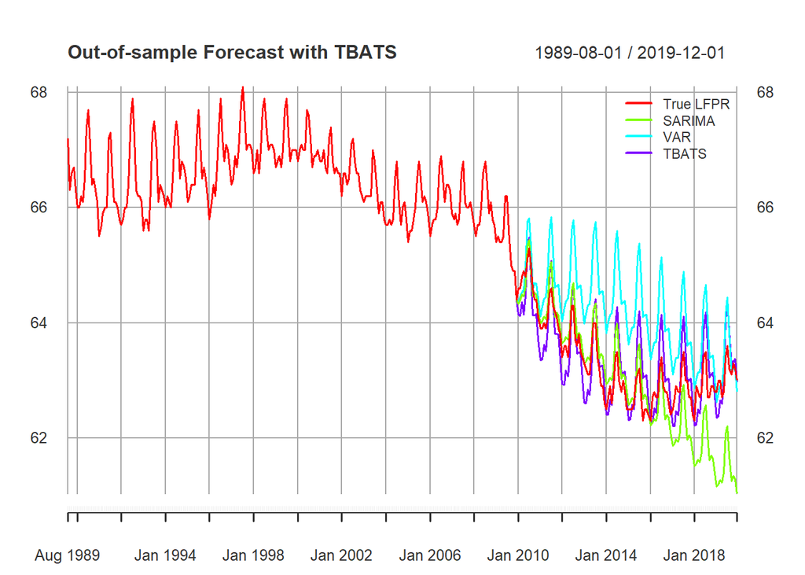

```r
addLegend("topright", col = colors, lty = 1, lwd = 2, cex = 0.8,
          legend.names = c('True LFPR', 'SARIMA', 'VAR', 'TBATS'))
```

TBATS model, when incorporating long term cycles, outperforms both SARIMA and VAR models.